# S04 T01: Visualització gràfica d'un dataset

```python
import pandas as pd
import matplotlib.pyplot as plt
import matplotlib.ticker as ticker
import numpy as np
import seaborn as sns
```

```python
df = pd.read_csv('/Users/deliagonzalezmata/Downloads/DelayedFlights.csv')
df = df [['UniqueCarrier', 'ArrDelay', 'DepDelay', 'AirTime', 'Year', 'Month', 'DayofMonth']]

df = df.rename(columns={'DayofMonth': 'Day'})
date = df[['Year', 'Month', 'Day']]
date.head()
df['Date'] = pd.to_datetime(date)

df = df.drop("Year",1)
df = df.drop("Day",1)
df = df.drop("Month",1)

df.head()
```

|  | UniqueCarrier | ArrDelay | DepDelay | AirTime | Date |
| --- | --- | --- | --- | --- | --- |
| 0 | WN | -14.0 | 8.0 | 116.0 | 2008-01-03 |
| 1 | WN | 2.0 | 19.0 | 113.0 | 2008-01-03 |
| 2 | WN | 14.0 | 8.0 | 76.0 | 2008-01-03 |
| 3 | WN | 34.0 | 34.0 | 77.0 | 2008-01-03 |
| 4 | WN | 11.0 | 25.0 | 87.0 | 2008-01-03 |

### Exercici 1: Resumeix gràficament el data set DelayedFlights.csv

#### Crea almenys una visualització per:

- Una variable categòrica (UniqueCarrier)
- Una variable numèrica (ArrDelay)
- Una variable numèrica i una categòrica (ArrDelay i UniqueCarrier)
- Dues variables numèriques (ArrDelay i DepDelay)
- Tres variables (ArrDelay, DepDelay i UniqueCarrier)
- Més de tres variables (ArrDelay, DepDelay, AirTime i UniqueCarrier).

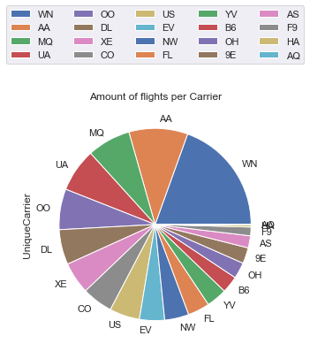

```python
# Una variable categòrica (UniqueCarrier)

carrier_counts = df['UniqueCarrier'].value_counts()
percentual = carrier_counts / carrier_counts.sum()
percentual.plot(kind = 'pie', legend=True)
plt.legend(loc="lower center", bbox_to_anchor=(0.5, 1.15), ncol=5)
plt.title('Amount of flights per Carrier')
plt.savefig('/Users/deliagonzalezmata/Documents/IT_Academy/Sprint_4/S04_T01/UniqueCarrier.png')
```

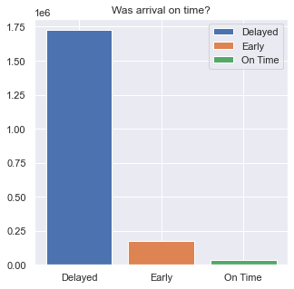

```python
# Una variable numèrica (ArrDelay)

def delay_func(x):
    if x > 0:
        return 'Delayed'
    if x < 0:
        return 'Early'
    else:
        return 'On Time'

df['Arrival Delay'] = df['ArrDelay'].apply(delay_func)

labels = []
for i, dfi in enumerate(df.groupby(["Arrival Delay"])):
    labels.append(dfi[0])
    plt.bar(i, dfi[1].count(), label=dfi[0])

plt.xticks(range(len(labels)), labels)
plt.legend()
plt.title('Was arrival on time?')
plt.savefig('/Users/deliagonzalezmata/Documents/IT_Academy/Sprint_4/S04_T01/ArrDelay.png')
plt.show()
```

En el gràfic anterior podem apreciar que la majoria de vols es retrassen en l'arribada mentre que molt pocs arriben a l'hora programada.

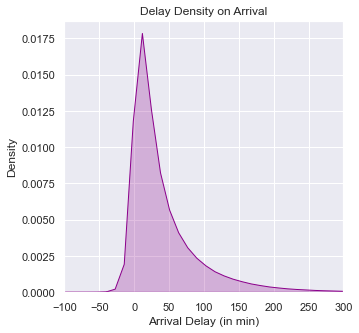

```python
sns.set(style="darkgrid")
sns.set(rc={'figure.figsize':(5,5)})

sns.kdeplot(df['ArrDelay'], shade=True, color = '#8B008B')
plt.xlim(-100,300)

plt.xlabel('Arrival Delay (in min)', horizontalalignment='center')
plt.title('Delay Density on Arrival')

plt.savefig('/Users/deliagonzalezmata/Documents/IT_Academy/Sprint_4/S04_T01/ArrDelay2.png')

plt.show()
```

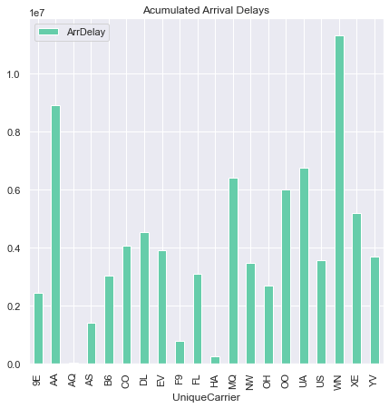

```python
# Una variable numèrica i una categòrica (ArrDelay i UniqueCarrier)
df_ArrDelay = df[['UniqueCarrier', 'ArrDelay']]
carrier_delay = df_ArrDelay.groupby('UniqueCarrier').aggregate(sum)

carrier_delay.plot(kind = 'bar', title = 'Acumulated Arrival Delays', color = '#66CDAA', figsize = (7, 7))

plt.savefig('/Users/deliagonzalezmata/Documents/IT_Academy/Sprint_4/S04_T01/ArrDelay_per_Carrier.png')
```

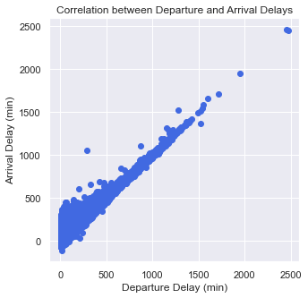

```python
# Dues variables numèriques (ArrDelay i DepDelay)

DepDelay = df['DepDelay']
ArrDelay = df['ArrDelay']

plt.figure(figsize = (5,5))
plt.scatter(DepDelay, ArrDelay, color = '#4169E1')

plt.xlabel('Departure Delay (min)')
plt.ylabel('Arrival Delay (min)')
plt.title('Correlation between Departure and Arrival Delays')

plt.savefig('/Users/deliagonzalezmata/Documents/IT_Academy/Sprint_4/S04_T01/Delays_correlation.png')

plt.show()
```

#### El gràfic mostra una clara correlació entre retards a la sortida i a l'arribada. Mirem ara si la correlació és manté igual per aerolinia:

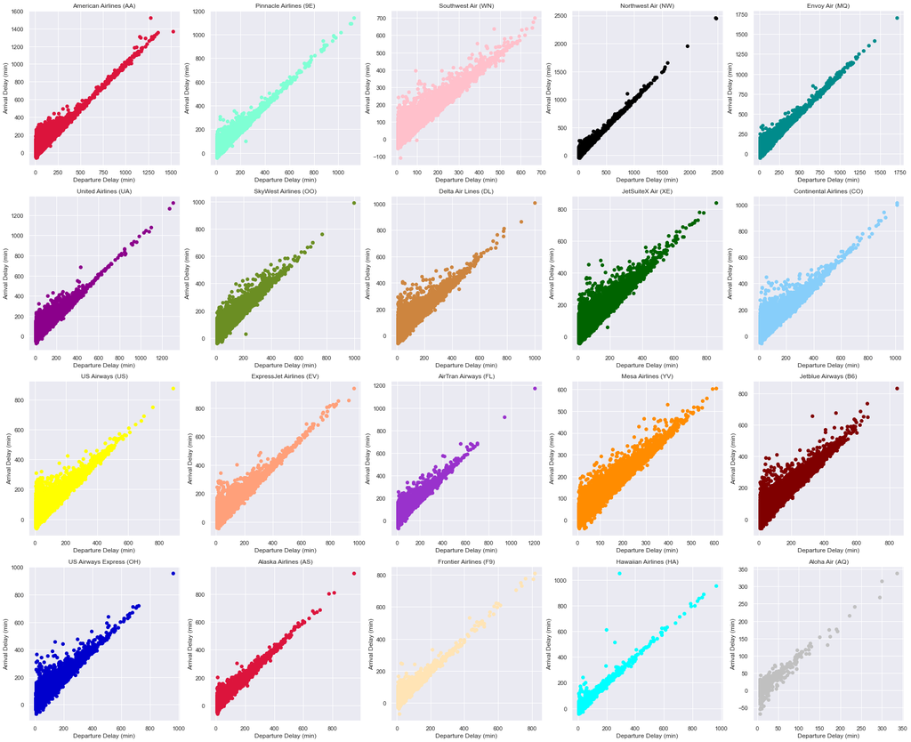

```python
# Tres variables (ArrDelay, DepDelay i UniqueCarrier)

df_tres = df[['DepDelay', 'ArrDelay', 'UniqueCarrier']]
grouped = df_tres.groupby(df['UniqueCarrier'])

fig, ((ax1, ax2, ax3, ax4, ax5),
      (ax6, ax7, ax8, ax9, ax10),
      (ax11, ax12, ax13, ax14, ax15),
      (ax16, ax17, ax18, ax19, ax20)) = plt.subplots(4,5, figsize=(30, 25))

#plot 1
AA = grouped.get_group('AA')

DepDelay = AA['DepDelay']
ArrDelay = AA['ArrDelay']

ax1.scatter(DepDelay, ArrDelay, color = '#DC143C')

ax1.set_xlabel('Departure Delay (min)')
ax1.set_ylabel('Arrival Delay (min)')
ax1.set_title('American Airlines (AA)')

#plot 2
AL = grouped.get_group('9E')

DepDelay = AL['DepDelay']
ArrDelay = AL['ArrDelay']

ax2.scatter(DepDelay, ArrDelay, color = '#7FFFD4')

ax2.set_xlabel('Departure Delay (min)')
ax2.set_ylabel('Arrival Delay (min)')
ax2.set_title('Pinnacle Airlines (9E)')

#plot 3
AL = grouped.get_group('WN')

DepDelay = AL['DepDelay']
ArrDelay = AL['ArrDelay']

ax3.scatter(DepDelay, ArrDelay, color = 'pink')

ax3.set_xlabel('Departure Delay (min)')
ax3.set_ylabel('Arrival Delay (min)')
ax3.set_title('Southwest Air (WN)')

#plot 4
AL = grouped.get_group('NW')

DepDelay = AL['DepDelay']
ArrDelay = AL['ArrDelay']

ax4.scatter(DepDelay, ArrDelay, color = '#000000')

ax4.set_xlabel('Departure Delay (min)')
ax4.set_ylabel('Arrival Delay (min)')
ax4.set_title('Northwest Air (NW)')

#plot 5
AL = grouped.get_group('MQ')

DepDelay = AL['DepDelay']
ArrDelay = AL['ArrDelay']

ax5.scatter(DepDelay, ArrDelay, color = '#008B8B')

ax5.set_xlabel('Departure Delay (min)')
ax5.set_ylabel('Arrival Delay (min)')
ax5.set_title('Envoy Air (MQ)')

#plot 6
AL = grouped.get_group('UA')

DepDelay = AL['DepDelay']
ArrDelay = AL['ArrDelay']

ax6.scatter(DepDelay, ArrDelay, color = '#8B008B')

ax6.set_xlabel('Departure Delay (min)')
ax6.set_ylabel('Arrival Delay (min)')
ax6.set_title('United Airlines (UA)')

#plot 7
AL = grouped.get_group('OO')

DepDelay = AL['DepDelay']
ArrDelay = AL['ArrDelay']

ax7.scatter(DepDelay, ArrDelay, color = 'OliveDrab')

ax7.set_xlabel('Departure Delay (min)')
ax7.set_ylabel('Arrival Delay (min)')
ax7.set_title('SkyWest Airlines (OO)')

#plot 8
AL = grouped.get_group('DL')

DepDelay = AL['DepDelay']
ArrDelay = AL['ArrDelay']

ax8.scatter(DepDelay, ArrDelay, color = '#CD853F')

ax8.set_xlabel('Departure Delay (min)')
ax8.set_ylabel('Arrival Delay (min)')
ax8.set_title('Delta Air Lines (DL)')

#plot 9
AL = grouped.get_group('XE')

DepDelay = AL['DepDelay']
ArrDelay = AL['ArrDelay']

ax9.scatter(DepDelay, ArrDelay, color = '#006400')

ax9.set_xlabel('Departure Delay (min)')
ax9.set_ylabel('Arrival Delay (min)')
ax9.set_title('JetSuiteX Air (XE)')

#plot 10
AL = grouped.get_group('CO')

DepDelay = AL['DepDelay']
ArrDelay = AL['ArrDelay']

ax10.scatter(DepDelay, ArrDelay, color = '#87CEFA')

ax10.set_xlabel('Departure Delay (min)')
ax10.set_ylabel('Arrival Delay (min)')
ax10.set_title('Continental Airlines (CO)')

#plot 11
AL = grouped.get_group('US')

DepDelay = AL['DepDelay']
ArrDelay = AL['ArrDelay']

ax11.scatter(DepDelay, ArrDelay, color = 'yellow')

ax11.set_xlabel('Departure Delay (min)')
ax11.set_ylabel('Arrival Delay (min)')
ax11.set_title('US Airways (US)')

#plot 12
AL = grouped.get_group('EV')

DepDelay = AL['DepDelay']
ArrDelay = AL['ArrDelay']

ax12.scatter(DepDelay, ArrDelay, color = '#FFA07A')

ax12.set_xlabel('Departure Delay (min)')
ax12.set_ylabel('Arrival Delay (min)')
ax12.set_title('ExpressJet Airlines (EV)')

#plot 13
AL = grouped.get_group('FL')

DepDelay = AL['DepDelay']
ArrDelay = AL['ArrDelay']

ax13.scatter(DepDelay, ArrDelay, color = '#9932CC')

ax13.set_xlabel('Departure Delay (min)')
ax13.set_ylabel('Arrival Delay (min)')
ax13.set_title('AirTran Airways (FL)')

#plot 14
AL = grouped.get_group('YV')

DepDelay = AL['DepDelay']
ArrDelay = AL['ArrDelay']

ax14.scatter(DepDelay, ArrDelay, color = '#FF8C00')

ax14.set_xlabel('Departure Delay (min)')
ax14.set_ylabel('Arrival Delay (min)')
ax14.set_title('Mesa Airlines (YV)')

#plot 15
AL = grouped.get_group('B6')

DepDelay = AL['DepDelay']
ArrDelay = AL['ArrDelay']

ax15.scatter(DepDelay, ArrDelay, color = '#800000')

ax15.set_xlabel('Departure Delay (min)')
ax15.set_ylabel('Arrival Delay (min)')
ax15.set_title('Jetblue Airways (B6)')

#plot 16
AL = grouped.get_group('OH')

DepDelay = AL['DepDelay']
ArrDelay = AL['ArrDelay']

ax16.scatter(DepDelay, ArrDelay, color = '#0000CD')

ax16.set_xlabel('Departure Delay (min)')
ax16.set_ylabel('Arrival Delay (min)')
ax16.set_title('US Airways Express (OH)')

#plot 17
AL = grouped.get_group('AS')

DepDelay = AL['DepDelay']
ArrDelay = AL['ArrDelay']

ax17.scatter(DepDelay, ArrDelay, color = '#DC143C')

ax17.set_xlabel('Departure Delay (min)')
ax17.set_ylabel('Arrival Delay (min)')
ax17.set_title('Alaska Airlines (AS)')

#plot 18
AL = grouped.get_group('F9')

DepDelay = AL['DepDelay']
ArrDelay = AL['ArrDelay']

ax18.scatter(DepDelay, ArrDelay, color = '#FFE4B5')

ax18.set_xlabel('Departure Delay (min)')
ax18.set_ylabel('Arrival Delay (min)')
ax18.set_title('Frontier Airlines (F9)')

#plot 19
AL = grouped.get_group('HA')

DepDelay = AL['DepDelay']
ArrDelay = AL['ArrDelay']

ax19.scatter(DepDelay, ArrDelay, color = '#00FFFF')

ax19.set_xlabel('Departure Delay (min)')
ax19.set_ylabel('Arrival Delay (min)')
ax19.set_title('Hawaiian Airlines (HA)')

#plot 20
AL = grouped.get_group('AQ')

DepDelay = AL['DepDelay']
ArrDelay = AL['ArrDelay']

ax20.scatter(DepDelay, ArrDelay, color = '#C0C0C0')

ax20.set_xlabel('Departure Delay (min)')
ax20.set_ylabel('Arrival Delay (min)')
ax20.set_title('Aloha Air (AQ)')

plt.savefig('/Users/deliagonzalezmata/Documents/IT_Academy/Sprint_4/S04_T01/correllation_per_carrier.png')

plt.show()
```

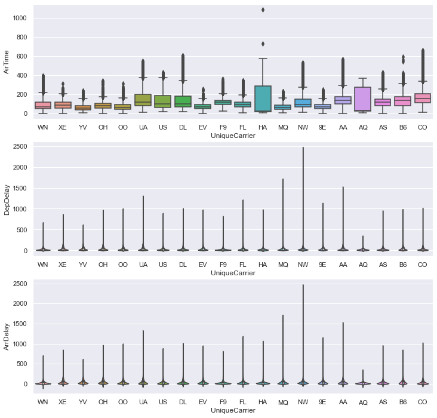

```python
# Més de tres variables (ArrDelay, DepDelay, AirTime i UniqueCarrier)

f, ax = plt.subplots(3, 1, figsize = (12, 12))

sns.boxplot(x= df["UniqueCarrier"], y= df["AirTime"], ax=ax[0])

sns.violinplot(x= df["UniqueCarrier"], y= df["DepDelay"], ax=ax[1])

sns.violinplot(x= df["UniqueCarrier"], y= df["ArrDelay"], ax=ax[2])

plt.savefig('/Users/deliagonzalezmata/Documents/IT_Academy/Sprint_4/S04_T01/4var.png')
```

### Exercici 2: Exporta els gràfics com imatges o com html.

He exportat les imatges en format png i es poden veure en el mateix repositori de Git, o fent click en el següent [enllaç](https://github.com/delia-gm/visualitzacio_exploratoria)

### Exercici 3: Integra les visualitzacions gràfiques en la tasca 5 de l'Sprint 3.

He modificat el notebook relatiu a S03 T05 afegint gràfiques a l'exploració de dades ja presentada. Es pot veure seguint el següent [enllaç](https://github.com/delia-gm/estructures_Dataframe).